# STAT 327 Homework 3

We’ll grade your homework by

- opening your “hw3.Rmd” file in RStudio
- clicking “Knit HTML”
- reading the HTML output
- reading your “hw3.Rmd”

You should write R code anywhere you see an empty R code chunk. You should write English text anywhere you see “…”; please surround it with doubled asterisks (`**...**`) so that it will show up as boldface and be easy for us to find.

Include reasonable labels (titles, axis labels, legends, etc.) with each of your graphs.

Name: Sirui Yi

Email: syi26@wisc.edu

We’ll use data on housing values in suburbs of Boston. They are in an R package called “MASS.” (An R package is a collection of code, data, and documentation. “MASS” refers to the book “Modern Applied Statistics with S.” R developed from the earlier language, S.) The MASS package comes with the default R installation, so it’s already on your computer. However, it’s not loaded into your R session by default. So we’ll load it via the `require()` command (there’s nothing for you to do here):

```r
require("MASS")
```

Run `?Boston` (outside this R Markdown document) to read the help page for the `Boston` data frame.

Convert the `chas` variable to a factor with labels “off” and “on” (referring to the Charles river).

```r
bos <- Boston
bos$chas <- factor(bos$chas, levels = c(0,1), labels = c("off", "on"))
```

How many rows are in the Boston data frame? How many columns?

```r
rows <- nrow(Boston)
cols <- ncol(Boston)
cat(sep = "", "There are ", rows, " rows and ", cols, " columns in Boston data frame.")
```

```
## There are 506 rows and 14 columns in Boston data frame.
```

What does a row represent? A row represents a neighborhood

What does a column represent? A column represents a variable for every neighborhood which would later be used to predict the median value (last column) of the house of interest.

Make a density plot (with rug) of tax rates.

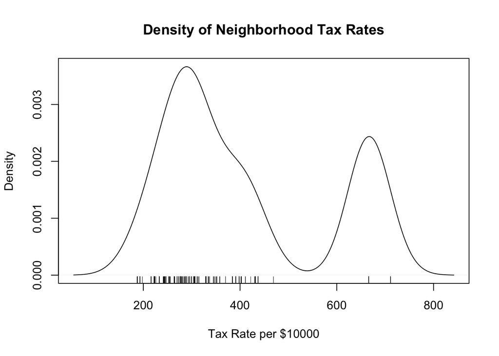

```r
plot(density(bos$tax), main = paste0("Density of Neighborhood Tax Rates"), xlab = "Tax Rate per $10000")
rug(bos$tax)
```

Describe the shape of the distribution of tax rates. The distribution is binomial.

Note that the distribution shape doesn’t make sense in light of the rug representation of the data. Make a histogram of the tax rates.

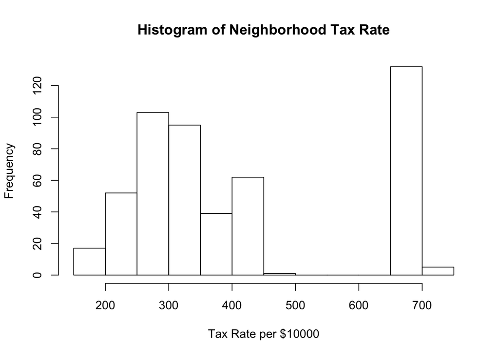

```r
hist(bos$tax, main = paste0("Histogram of Neighborhood Tax Rate"), xlab = "Tax Rate per $10000")
```

Why is the second peak of the density plot so large? In what way is the rug representation of the data inadequate? Write a line or two of code to figure it out, and then explain it.

```r
tax.table <- table(bos$tax)
tax.table[names(tax.table) > 600]
```

```
##
## 666 711
## 132   5
```

The second peak in the density plot is large because there are 132 neighborhoods that have the same tax rate higher than 600. This might because after a certain value of income, the tax rate became fixed, so that rug is also inadequate because it fails to show the amount of houses that share this exactly same rate.

Make a barplot of “chas”.

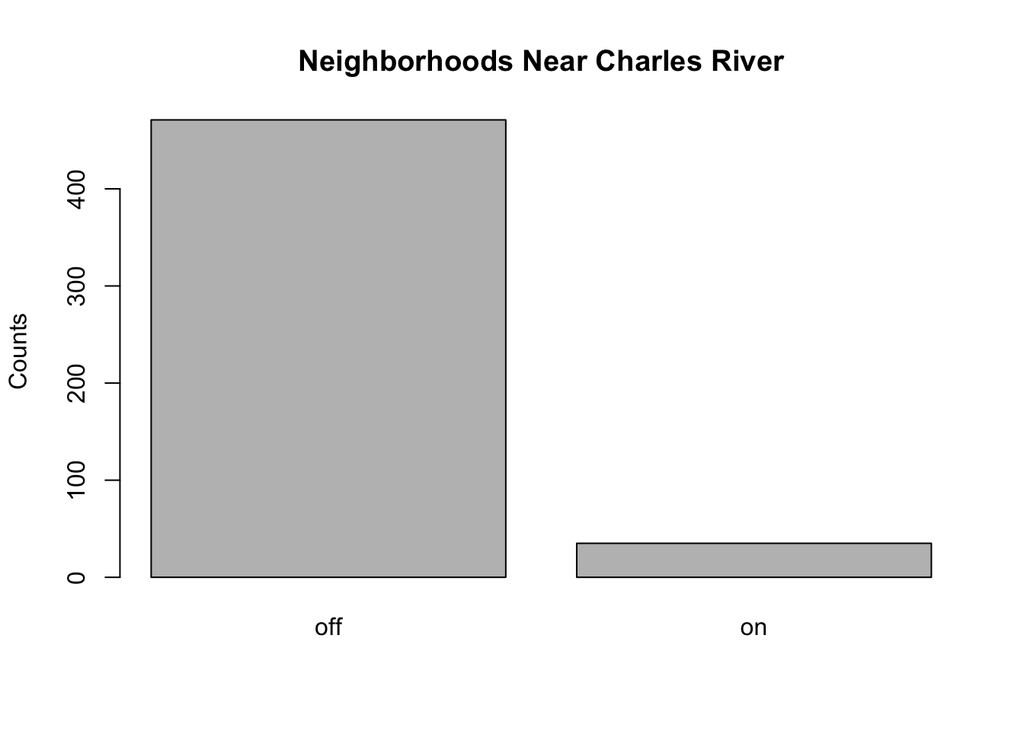

```r
barplot(table(bos$chas), main = paste0("Neighborhoods Near Charles River"), ylab = "Counts")
```

How many neighborhoods are on the Charles river?

```r
table(bos$chas)
```

```
##
## off  on
## 471  35
```

```r
cat(sep = "", "There are 35 neighborhoods on the Charles river.")
```

```
## There are 35 neighborhoods on the Charles river.
```

Make a single graph consisting of three plots:

- a scatterplot of “nox” on the y-axis vs. “dis” on the x-axis
- a (vertical) boxplot of “nox” left of the scatterplot’s y-axis
- a (horizontal) boxplot of “dis” below the scatterplot’s x-axis

Hint: use `layout()` with a 4x4 matrix, using the top-right 3x3 corner for the scatterplot, leaving the bottom-left 1x1 corner blank, and using the other parts for the boxplots.

(An optional challenge, worth 0 extra credit points: remove the axis and plot border from each boxplot.)

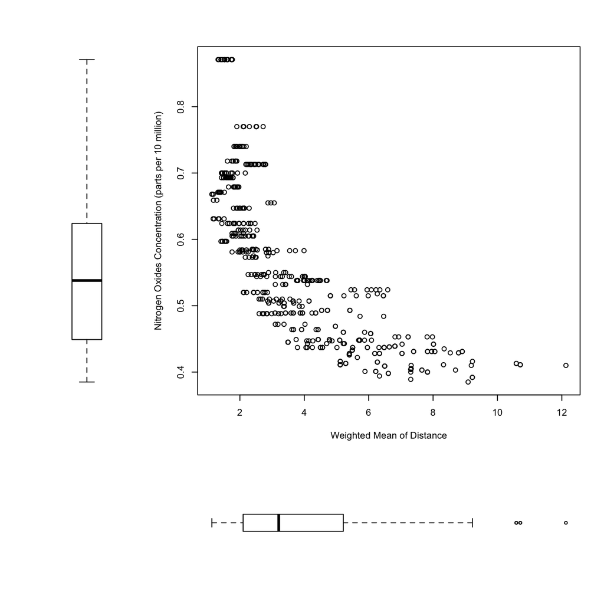

```r
m <- matrix(data = c(2,1,1,1,2,1,1,1,2,1,1,1,0,3,3,3), nrow = 4, ncol = 4, byrow = TRUE)
layout(m)
plot(bos$dis, bos$nox, xlab = "Weighted Mean of Distance", ylab = "Nitrogen Oxides Concentration (parts per 10 million)")
boxplot(bos$nox, frame = FALSE, axes = FALSE)
boxplot(bos$dis, horizontal = TRUE, frame = FALSE, axes = FALSE)
```

Look into the highest-crime neighborhood by making a single graph of one column of three rows:

- Find the row number, r, of the neighborhood with the highest “crim”.
- Make a density plot of “crim”. Include a rug to show the data.
- Add a red circle at (x, y) = (max crime rate, 0) to make this maximum crime rate stand out.
- Make a density plot with rug of “medv”, adding a red circle at (x, y) = (medv[r], 0) to see what medv corresponds to the highest crime rate.
- Repeat the last step for “ptratio”.

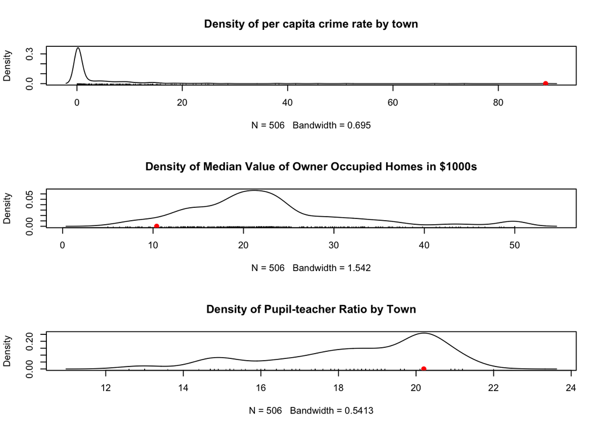

```r
b1 = bos[which.max(bos$crim),]
# r = 381
layout(matrix(c(1,2,3), nrow = 3, ncol = 1))
plot(density(bos$crim), main = paste0("Density of per capita crime rate by town"))
rug(bos$crim)
points(bos$crim[which.max(bos$crim)], 0, col = "red", pch = 19)
plot(density(bos$medv), main = paste0("Density of Median Value of Owner Occupied Homes in $1000s"))
rug(bos$medv)
points(bos$medv[which.max(bos$crim)], 0, col = "red", pch = 19)
plot(density(bos$ptratio), main = paste0("Density of Pupil-teacher Ratio by Town"))
rug(bos$ptratio)
points(bos$ptratio[which.max(bos$crim)], 0, col = "red", pch = 19)
```

What do you notice about the ptratio and medv for the highest-crime neighborhood?